# Predictive modeling: basic notions

Statistical Learning  
James Scott (UT-Austin)

Reference: Introduction to Statistical Learning, Chapters 1-2

### Outline

1. Introduction
2. Measuring accuracy
3. Out-of-sample predictions
4. Bias-variance tradeoff
5. Classification
6. Train/test splits
7. K-nearest neighbors

### Introduction to predictive modeling

The goal is to predict a target variable (\( y \)) with feature variables (\( x \)).

- Zillow: predict price (\( y \)) using a house's features (\( x \) = size, beds, baths, age, …)
- Citadel: predict next month's S&P (\( y \)) using this month's macroeconomic indicators (\( x \) = unemployment, GDP growth rate, inflation, …)
- MD Anderson: predict a patient's disease progression (\( y \)) using his or her clinical, demographic, and genetic indicators (\( x \))
- Etc.

In data mining/ML/AI, this is called “supervised learning.”

### Introduction to predictive modeling

A useful way to frame this problem is to think that \( y \) and \( x \) are related like this:

\[ y_i = f(x_i) + e_i \]

where:

- \( y_i \) is a scalar *outcome* or *target* variable
- \( x_i = (x_{i1}, x_{i2}, ... x_{iP}) \) is a vector of features
- \( f \) is an unknown function

In the first half of this course, our main purpose is to *learn* \( f(x) \) from the observed data.

### Example: predicting electricity demand

[figure not shown]

### Example: predicting electricity demand

ERCOT operates the electricity grid for 75% of Texas.

The 8 ERCOT regions are shown at right.

We'll focus on a basic prediction task:

- \( y \) = demand (megawatts) in the Coast region at 3 PM, every day from 2010-2016.
- \( x \) = average daily tempature measured at Houston's Hobby Airport (degrees Celsius)

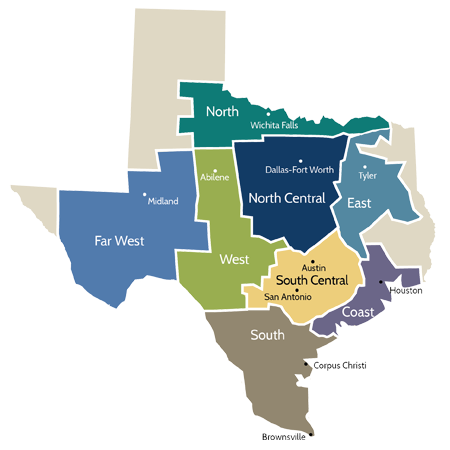

### Slide With Code

```r
summary(cars)
```

```
     speed           dist
 Min.   : 4.0   Min.   :  2.00
 1st Qu.:12.0   1st Qu.: 26.00
 Median :15.0   Median : 36.00
 Mean   :15.4   Mean   : 42.98
 3rd Qu.:19.0   3rd Qu.: 56.00
 Max.   :25.0   Max.   :120.00
```

### Slide With Plot

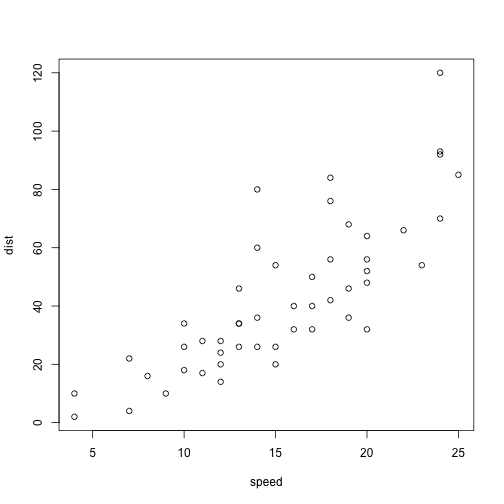